# Математическое моделирование

Лабораторная работа № 2

Наталья Ларина

1132236025@rudn.ru

Российский университет дружбы народов

2026-02-23

# Вводная часть

## Цель работы

Показать, как строится математическая модель, позволяющая выбрать стратегию поиска и преследования.

Ситуация: в тумане катер береговой охраны преследует лодку браконьеров. В момент кратковременного прояснения лодка обнаруживается на расстоянии $k$ км от катера, затем снова скрывается и продолжает прямолинейное движение в неизвестном направлении. Скорость катера в $n$ раз выше скорости лодки. Требуется найти траекторию катера, обеспечивающую перехват.

## Задание

1. Выполнить рассуждения и получить дифференциальные уравнения для случая, когда скорость катера превышает скорость лодки в $n$ раз.
2. Построить траектории движения катера и лодки для двух вариантов начальных условий.
3. По графику определить момент перехвата (точку пересечения траекторий).

# Теория: постановка и вывод модели

## Обозначения и выбор координат

Положим $t_0=0$.

В момент обнаружения:

- лодка находится в точке $X_0=0$,
- катер удалён от неё на $k$, то есть относительно полюса $X_0=k$.

Переходим к полярным координатам:

- полюс — точка обнаружения лодки,
- ось $r$ направлена через начальное положение катера.

## Радиус перехода к обходной траектории

Найдём расстояние $x$, при котором катер и лодка оказываются на одном и том же радиусе относительно полюса.

За время $t$:

- лодка проходит путь $x$,
- катер проходит $x-k$ или $x+k$ (в зависимости от начальной конфигурации).

Равенство времён движения приводит к двум режимам начальных условий.

## Два режима начальных условий

- **case = plus**:
  $$x_1=\frac{k}{n+1}, \quad \theta_0=0$$
- **case = minus**:
  $$x_2=\frac{k}{n-1}, \quad \theta_0=-\pi$$

Эти значения задают стартовый радиус для дальнейшего движения катера вокруг полюса.

## Уравнение траектории катера

После исключения параметра времени из системы получаем ОДУ траектории:
$$\frac{dr}{d\theta}=\frac{r}{\sqrt{n^2-1}}.$$

Следствие: траектория катера в полярных координатах имеет вид экспоненциально расходящейся спирали.

# Эксперимент: численное моделирование

## Исходные данные для расчётов

Задано:

- расстояние обнаружения $k=20$ км,
- превосходство скорости катера $n=5$.

Цель моделирования: построить траектории катера и лодки и определить точку перехвата как пересечение кривых.

## Базовый эксперимент: case = plus (график)

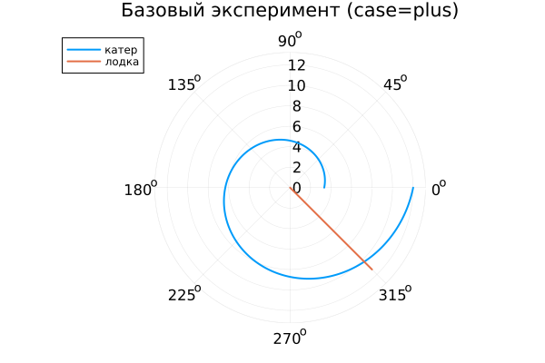

## Базовый эксперимент: case = plus (интерпретация)

Наблюдается:

- траектория катера — расходящаяся спираль;
- радиус $r$ возрастает при росте $\theta$;
- траектория лодки в полярных координатах соответствует лучу (прямолинейному движению в декартовой системе).

## Базовый эксперимент: case = minus (график)

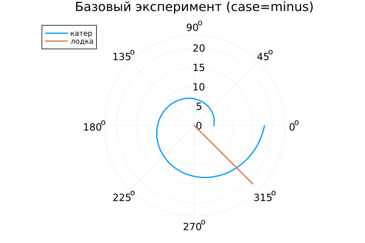

## Базовый эксперимент: case = minus (интерпретация)

По сравнению с режимом case=plus:

- стартовый радиус больше, поэтому траектория «вынесена» дальше от полюса;
- форма кривой сохраняется, изменяется только масштаб и начальная позиция.

# Параметрический анализ

## Сканирование по параметру $n$ (график)

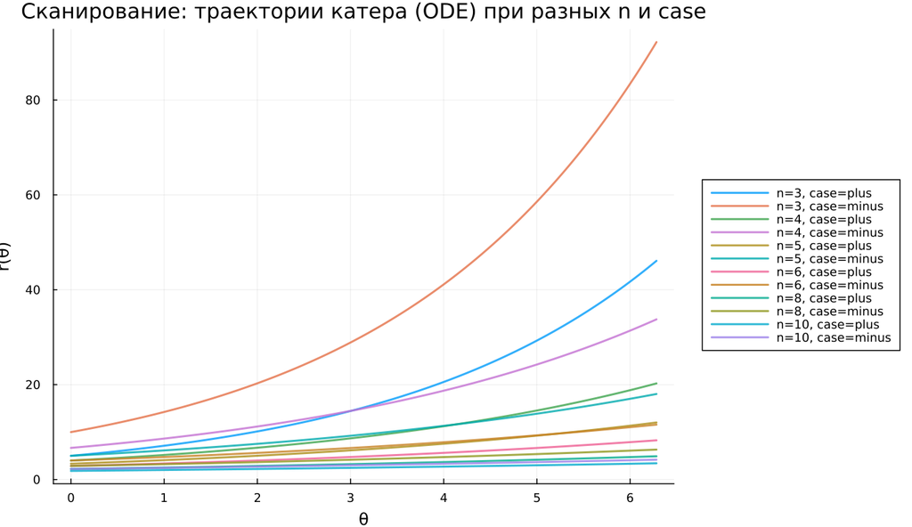

## Сканирование по параметру $n$ (вывод)

Из уравнения
$$\frac{dr}{d\theta}=\frac{r}{\sqrt{n^2-1}}$$
следует, что темп роста задаётся коэффициентом $1/\sqrt{n^2-1}$, поэтому:

- при меньших $n$ спираль расходится быстрее;
- при больших $n$ радиус растёт медленнее;
- траектории становятся визуально более «пологими».

## Метрика scale_ratio (определение)

Введём показатель относительного масштаба:
$$\text{scale\_ratio}=\frac{r_{\text{final}}}{\max(r_{\text{boat}})}.$$

Он сравнивает конечный радиус катера с максимальным радиусом лодки в рамках моделирования.

## Метрика scale_ratio (график)

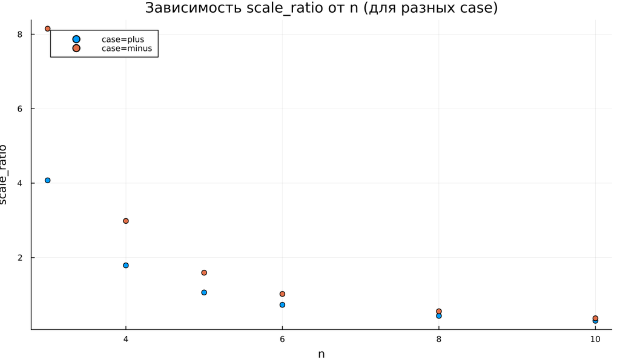

## Метрика scale_ratio (объяснение)

По результатам:

В режиме case=minus значения выше из-за большего начального радиуса.

## Время вычислений (график)

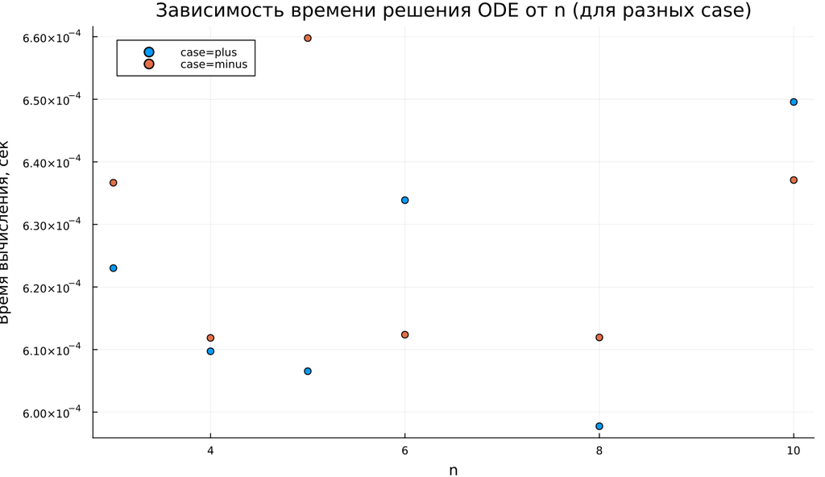

## Время вычислений (комментарий)

По бенчмаркингу:

- время расчёта порядка $6\times10^{-4}$ сек;
- заметной зависимости от $n$ не выявлено;
- небольшие колебания связаны с адаптивным шагом интегрирования.

# Итоги

## Выводы

1. Траектория катера в полярных координатах описывается экспоненциально расходящейся спиралью.
2. Параметр $n$ управляет темпом радиального роста: при большем $n$ рост $r$ по $\theta$ замедляется.
3. Режим начальных условий (case) меняет масштаб и стартовую позицию, но не тип траектории.
4. Численное решение устойчиво, а вычислительные затраты слабо зависят от параметров модели.